# Appendix B: Re-analysis of original data (Shebani and Pulvermüller, 2013)

[Guillermo Montero-Melis](https://www.mpi.nl/people/montero-melis-guillermo)

12/12/2019

# 1 Introduction

This report presents a re-analysis of the original data from the study Shebani and Pulvermüller (2013, *Cortex*, hereafter SP13). In the script we:

- Plot and summarize the data to check we obtain the same summaries as in SP13;
- Replicate the same ANOVAs reported in the original;
- Try to figure out how SP13 arrived at the effect size measure they report;
- Re-analyze the data with more appropriate statistical methods.

*NB*:

- The original data have been made publicly available by the original authors at https://github.com/zshebani/LMB/tree/1.0 (DOI: 10.5281/zenodo.3402035).
- Some of the analyses and simulations run below take up a considerable amount of computation time. In these cases we have saved the output of the code to disk (to the “data/” subfolder) so that it can later be read without the need to re-run the analyses. If you wish to re-run the analyses, please uncomment the relevant code.
- For R version, loaded packages and their versions, etc., see session info at the end of this document.

# 2 Setup workspace

Load libraries

```r
library("knitr")
library("lme4")
library("brms")
library("tidyverse")  # ggplot2, dplyr, readr, purrr, etc
library("boot")       # for inv.logit()
library("DescTools")  # EtaSq()
library("lsr")        # cohensD()
library("sjPlot")     # tab_model()
# library("sjstats")    # eta_sq()
```

Load original data set:

```r
# Load data
d_allconds <- read_csv("data/SP13_orig-data_total-errors_long-format.csv")
d_allconds$subject <- factor(d_allconds$subject)
```

# 3 Describe and plot the data set

```r
kable(head(d_allconds))
```

| subject | movement | word_type | errors |
| --- | --- | --- | --- |
| 1 | arm_paradi | arm | 14 |
| 1 | arm_paradi | leg | 10 |
| 1 | artic_suppression | arm | 22 |
| 1 | artic_suppression | leg | 24 |
| 1 | control | arm | 9 |
| 1 | control | leg | 8 |

- The data frame shows the total number of errors, adding all three types of errors: omissions, replacements, and transpositions.
- This data set contains the data for all four movement conditions: arm_paradi, artic_suppression, control, leg_paradi. However, we are only interested in the two critical arm/leg movement conditions (“arm_paradi” and “leg_paradi”), so we subset the relevant data:

```r
d <- d_allconds %>% filter(movement %in% c("arm_paradi", "leg_paradi"))
```

Plot the data:

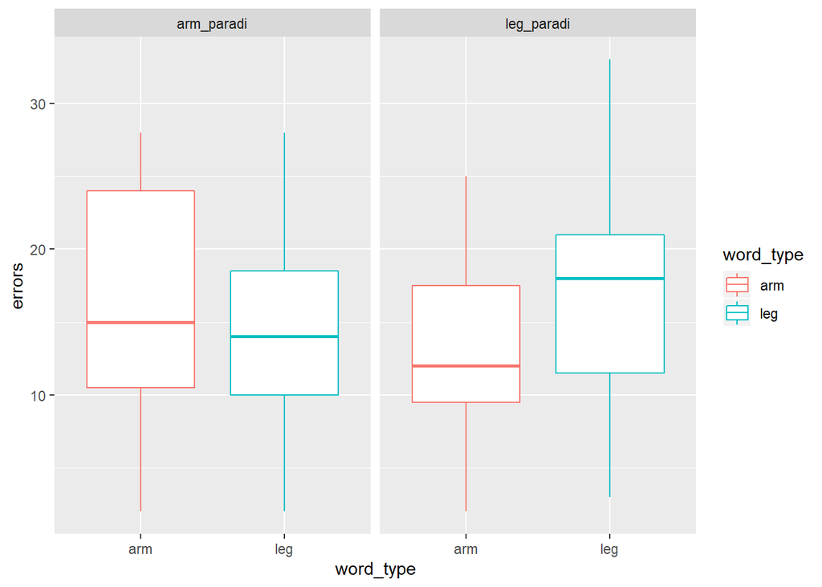

```r
ggplot(d, aes(x = word_type, y = errors, colour = word_type)) +
  geom_boxplot() +
  facet_grid(. ~ movement)
```

We can qualitatively see the cross-over interaction. Note that although the variability is large, a hypothetical effect may still be detected if there is sufficient consistency within subjects, as it is a within-subjects design. This can be better appreciated in the following plot:

```r
# basic plot
plot_orig <- d %>%
  mutate(sbj_wtype = paste(subject, word_type, sep = "_")) %>%
  mutate(movement  = ifelse(movement == "arm_paradi", "arm\nmovements", "leg\nmovements"),
         word_type = ifelse(word_type == "arm", "arm words", "leg words")) %>%
  ggplot(aes(x = movement, colour = word_type, y = errors)) +
  stat_summary(fun.y = mean, geom = "point", size = 4,
               position = position_dodge(width = .25)) +
  stat_summary(fun.y = mean, geom = "line", aes(group = word_type), size = 2,
               position = position_dodge(width = .25)) +
  stat_summary(fun.data = mean_cl_boot, geom = "errorbar", width = 0.2, size = 2,
               position = position_dodge(width = .25)) +
  xlab("") + ylab("Number of errors") +
  theme_classic() +
  theme(legend.title = element_blank(),
        legend.position="top")
```

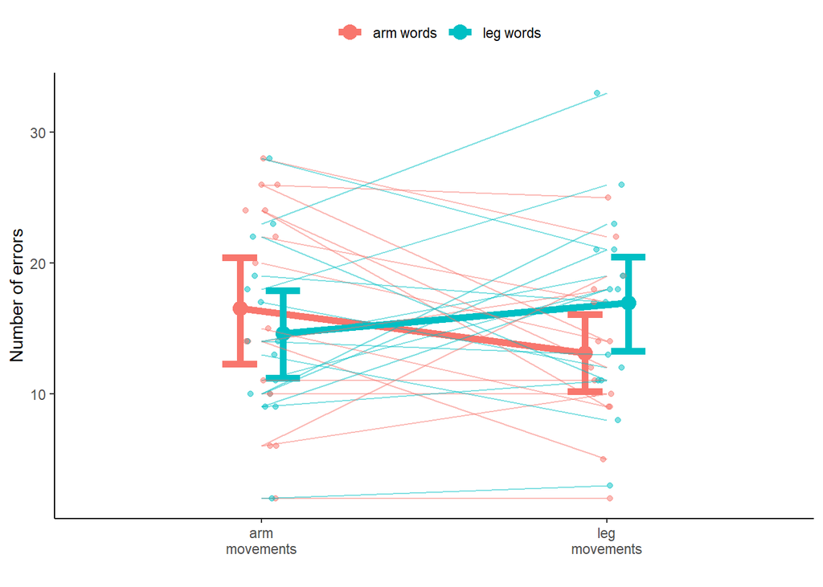

```r
# Plot for report
plot_orig +
  geom_jitter(height = 0, width = .05, alpha = .5) +
  geom_line(aes(group = sbj_wtype), alpha = .5)
```

The thick dots and lines show mean number of errors and bootstrapped (non-parametric) 95% CIs. The thinner dots and lines show subject data. There seems to be quite a lot of consistency by subjects, i.e. the slopes of the thin lines mostly go in the same direction as the slope of the thicker lines.

```r
# Create a png version to add in the paper:
if(! dir.exists("myfigures")) dir.create("myfigures")
ggsave("myfigures/fig_original_results.png",
       plot_orig + theme(text = element_text(size=18)),
       width = 4.5, height = 3)
```

# 4 Replicate originally reported analysis with ANOVAs

## 4.1 Data summaries

First, let’s see if our data summaries look like those reported in Table 2 of SP13 (p.226):

```r
d_allconds %>%
  group_by(movement, word_type) %>%
  summarise(
    M  = round(mean(errors), 1),
    SD = round(sd(errors), 2)
  )
```

```
## # A tibble: 8 x 4
## # Groups:   movement [4]
##   movement          word_type     M    SD
##   <chr>             <chr>     <dbl> <dbl>
## 1 arm_paradi        arm        16.5  8.39
## 2 arm_paradi        leg        14.6  6.66
## 3 artic_suppression arm        22    7.69
## 4 artic_suppression leg        19.6  5.91
## 5 control           arm         7.2  4.97
## 6 control           leg         8.3  4.19
## 7 leg_paradi        arm        13.1  6.23
## 8 leg_paradi        leg        16.9  7.56
```

Yes, this replicates the values in Table 2!

## 4.2 Anova on full 4 (conditions) x 2 (word categories) design:

Can we replicate the results reported in SP13 (p.225)?

```r
# Following this post:
# https://www.r-bloggers.com/two-way-anova-with-repeated-measures/
aov_orig_allconds <- aov(
  errors ~ movement * word_type + Error(subject / (movement * word_type)),
  data = d_allconds
  )
summary(aov_orig_allconds)
```

```
##
## Error: subject
##           Df Sum Sq Mean Sq F value Pr(>F)
## Residuals 14   2801   200.1
##
## Error: subject:movement
##           Df Sum Sq Mean Sq F value   Pr(>F)
## movement   3   2583   861.1   23.77 3.77e-09 ***
## Residuals 42   1522    36.2
## ---
## Signif. codes:  0 '***' 0.001 '**' 0.01 '*' 0.05 '.' 0.1 ' ' 1
##
## Error: subject:word_type
##           Df Sum Sq Mean Sq F value Pr(>F)
## word_type  1   0.68   0.675   0.049  0.828
## Residuals 14 192.70  13.764
##
## Error: subject:movement:word_type
##                    Df Sum Sq Mean Sq F value   Pr(>F)
## movement:word_type  3  188.5   62.83   7.635 0.000349 ***
## Residuals          42  345.6    8.23
## ---
## Signif. codes:  0 '***' 0.001 '**' 0.01 '*' 0.05 '.' 0.1 ' ' 1
```

Yes, pretty much: The *F*- and *p*-values are identical. What differs are the MSE and I am not sure how they were computed.

## 4.3 Anova on critical 2 x 2 design

Most importantly, can we replicate the critical results “directly addressing the main hypothesis motivating this study” (SP13, p.226)?

```r
aov_orig <- aov(
  errors ~ movement * word_type + Error(subject / (movement * word_type)),
  data = d
  )
summary(aov_orig)
```

```
##
## Error: subject
##           Df Sum Sq Mean Sq F value Pr(>F)
## Residuals 14   2039   145.7
##
## Error: subject:movement
##           Df Sum Sq Mean Sq F value Pr(>F)
## movement   1    4.3    4.27   0.096  0.761
## Residuals 14  620.2   44.30
##
## Error: subject:word_type
##           Df Sum Sq Mean Sq F value Pr(>F)
## word_type  1  13.07   13.07   1.169  0.298
## Residuals 14 156.43   11.17
##
## Error: subject:movement:word_type
##                    Df Sum Sq Mean Sq F value  Pr(>F)
## movement:word_type  1  123.3  123.27   12.67 0.00314 **
## Residuals          14  136.2    9.73
## ---
## Signif. codes:  0 '***' 0.001 '**' 0.01 '*' 0.05 '.' 0.1 ' ' 1
```

Again, pretty much yes: The *F*-values, degrees of freedom and *p*-values are identical. Still their reported MSE differs from what we obtained above.

## 4.4 Effect size: Where does the originally reported Cohen’s $d$ come from?

The authors report Cohen’s $d = 1.25$ as the effect size for the critical interaction (p.226). However, since Cohen’s *d* is not an effect size measure that is commonly reported in the context of ANOVAs, it is not clear how they arrived at this figure. Below we try to reproduce it.

### 4.4.1 Does the *d* value come from a t-test?

What if we compare the average difference scores corresponding to the interaction effect, i.e. we compare for each subject the average number of errors when effector and word type coincide (arm-arm or leg-leg) and when they differ (arm-leg or leg-arm):

```r
d$eff_word <- ifelse(substr(d$movement,1,3) == d$word_type, "match", "mismatch")
head(d, 4)
```

```
## # A tibble: 4 x 5
##   subject movement   word_type errors eff_word
##   <fct>   <chr>      <chr>      <dbl> <chr>
## 1 1       arm_paradi arm           14 match
## 2 1       arm_paradi leg           10 mismatch
## 3 1       leg_paradi arm           18 mismatch
## 4 1       leg_paradi leg           21 match
```

```r
d_interact <- d %>%
  group_by(subject, eff_word) %>%
  summarise(errors = mean(errors))
head(d_interact)
```

```
## # A tibble: 6 x 3
## # Groups:   subject [3]
##   subject eff_word errors
##   <fct>   <chr>     <dbl>
## 1 1       match      17.5
## 2 1       mismatch   14
## 3 2       match       2.5
## 4 2       mismatch    2
## 5 3       match      25
## 6 3       mismatch   13.5
```

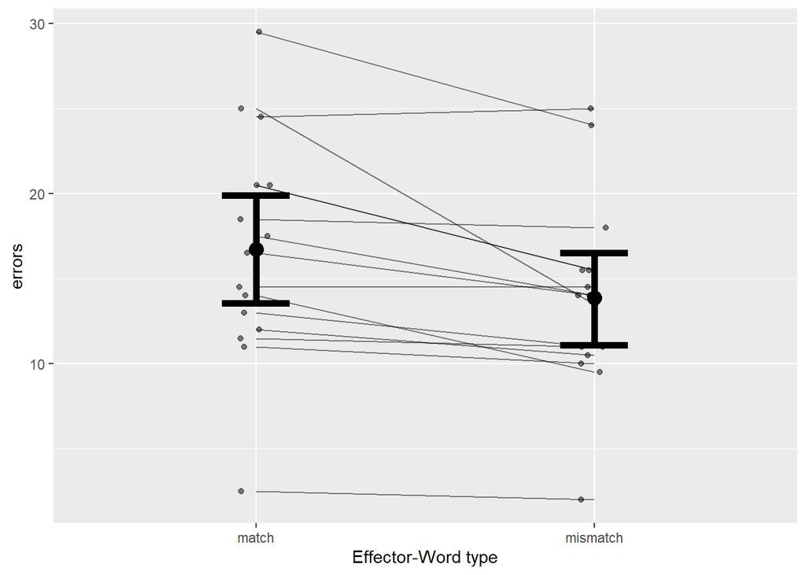

```r
ggplot(d_interact, aes(x = eff_word, y = errors)) +
  geom_jitter(height = 0, width = .05, alpha = .5) +
  geom_line(aes(group = subject), alpha = .5) +
  stat_summary(fun.y = mean, geom = "point", size = 4,
               position = position_dodge(width = .25)) +
  stat_summary(fun.data = mean_cl_boot, geom = "errorbar", width = 0.2, size = 2,
               position = position_dodge(width = .25)) +
  xlab("Effector-Word type")
```

```r
d_4ttest <- spread(d_interact, eff_word, errors)
head(d_4ttest, 3)
```

```
## # A tibble: 3 x 3
## # Groups:   subject [15]
##   subject match mismatch
##   <fct>   <dbl>    <dbl>
## 1 1        17.5     14
## 2 2         2.5      2
## 3 3        25       13.5
```

```r
with(d_4ttest, t.test(match, mismatch, paired = TRUE))
```

```
##
##  Paired t-test
##
## data:  match and mismatch
## t = 3.5591, df = 14, p-value = 0.003143
## alternative hypothesis: true difference in means is not equal to 0
## 95 percent confidence interval:
##  1.139174 4.594159
## sample estimates:
## mean of the differences
##                2.866667
```

Cohen’s $d$:

```r
# Following https://rcompanion.org/handbook/I_04.html
with(d_4ttest, (mean(match) - mean(mismatch)) / sd(match - mismatch))
```

```
## [1] 0.9189662
```

```r
# Note we get the same value using the lsr package
with(d_4ttest, lsr::cohensD(mismatch, match, method = "paired"))
```

```
## [1] 0.9189662
```

No; we obtain a Cohen’s $d = 0.92$, unlike the figure reported in SP13.

### 4.4.2 Computing $d$ from (partial) $\eta^2$?

Eta squared ($\eta^2$) is the most commonly used measure of effect size for ANOVAs: It “measures the proportion of the total variance in a dependent variable that is associated with […] an independent variable” (Richardson, 2011, p. 135; for an example calculation, see [here](https://psychohawks.wordpress.com/2010/10/31/effect-size-for-analysis-of-variables-anova/)).

```r
eta_sq <- DescTools::EtaSq(aov_orig, type = 1)
eta_sq
```

```
##                         eta.sq eta.sq.part  eta.sq.gen
## movement           0.001379637 0.006832132 0.001443262
## word_type          0.004225140 0.077089479 0.004406871
## movement:word_type 0.039858587 0.475016057 0.040083245
```

```r
# sjstats::eta_sq(aov_orig)  # yields same results
```

The value for the critical movement–word type interaction of interest is one of two:

1. $\eta^2 = 0.04$
2. partial $\eta^2 = 0.48$.

We tried two methods of converting (partial) $\eta^2$ to Cohen’s $d$ and we computed two values with each method, once for $\eta^2$ and once for partial $\eta^2$:

1. [This online calculator](https://www.psychometrica.de/effect_size.html) converts between different effect size measures (see section 13):
   1. When plugging in $\eta^2 = 0.04$, the corresponding effect size is $d = 0.41$, which is far off from the figure reported in SP13.
   2. When plugging in partial $\eta^2 = 0.48$, the corresponding effect size is $d = 1.92$, which is also different from that reported in the original (but in this case, it is greater).
2. [This IBM support website](https://www-01.ibm.com/support/docview.wss?uid=swg21476421) cites formulae to convert between $\eta^2$, Cohen’s $f$, and Cohen’s $d$:
   $$f = \sqrt{ \frac{\eta^2}{1 - \eta^2} };
   d = 2*f$$
   This formula yields exactly the same results as above:
   1. $d=0.41$ if computed from the $\eta^2$,
   2. $d=1.92$ if computed from the partial $\eta^2$.

# 5 Treat data as coming from a binomial distribution, but what is $n$?

SP13 analyzed their data using ANOVAs and t-tests. We instead want to model the dependent variable (DV = number of errors per experimental cell) as coming from a binomial distribution:

$$errors \sim B(n, p)$$

Here, $n$ is the upper bound on the possible number of errors and $p$ is the probability of making an error for each word. We will assume that the maximum number of errors for each trial (i.e., sequence of 4 words) is 4. However, we also need to determine how many trials there were per cell and this is slightly tricky, because SP13 report this inconsistently (see below).

We emailed the original authors about this. Here is the relevant extract, with the authors’ responses as inline comments (email correspondence with Z. Shebani from 1 Apr 2018):

> **Number of trials**

> It says that 24 trials were presented in each block, twelve arm-word and 12 leg-word trials (sect. 2.3, p.225 left column [=LC]). It also says that 4 words were presented per trial (sect. 2.3, p.224 right column [=RC]). This implies that 48 words of each category were shown per block. Since the lists consist of 36 words per category, the above would suggest that some words were repeated in each block (e.g., 12 words per category repeated once), but this is not explicitly stated. Was this the case?

> > Yes, 48 words from each category were shown in each block. Twelve words per category, randomly selected, were repeated once in each block.

> It then says that conditions were run as separate blocks (sect. 2.3, p.225 LC) and that the full set of 72 words were presented twice in each condition (sect. 2.3, p.225 RC). These figures don’t seem to add up: For 72 * 2 = 144 words to be presented, this would require 144 / 4 = 36 trials (assuming 4 words are presented in each trial). In other words, one would need 1.5 blocks per condition, whereas in the study it says that “the conditions were run as separate blocks with twenty-four trials in each block” (p.225). Is there perhaps a typo in the reported numbers, or do we err in our reasoning? In sum, what was the exact number of words per trial, trials per block (we assume equal number of leg- and arm-word trials), and blocks per condition?

> > Line 2 of page 225, RC does indeed contain a typo. As mentioned above, 48 words from each category were presented in each block (36 +12 = 48), therefore, not all words were repeated twice in each block/condition.

> > In sum:

> > Words per trial: 4

> > Trials per block: 24 (12 arm word and 12 leg word trials)

> > Blocks in the experiment: 4

> > Blocks per condition: 1

**Conclusion**

Based on this correspondence, we take there to be 12 trials per experimental cell. Since we assume the maximum number of errors per trial is 4, $n = 12 \times 4 = 48$.

The basic probabilistic model is
$$errors \sim B(48, p)$$
and we are trying to estimate *p*.

```r
d$n <- 48
```

# 6 Bayesian GLMM (binomial mixed model) with *brms*

We fit a binomial model using the same priors as we are going to use in our replication:

- Weakly informative priors for all population-level fixed effects coefficients: $N(0,\sigma^2 = 4)$;
- `brms`’s default priors for the variance components (random effects).

## 6.1 Fit the model

First, set coding scheme to contrast coding:

```r
# movement condition
d$movement <- factor(d$movement)
contrasts(d$movement) <- contr.sum(2)
colnames(contrasts(d$movement)) <- "arm_vs_leg"
contrasts(d$movement)
```

```
##            arm_vs_leg
## arm_paradi          1
## leg_paradi         -1
```

```r
# word type
d$word_type <- factor(d$word_type)
contrasts(d$word_type) <- contr.sum(2)
colnames(contrasts(d$word_type)) <- "arm_vs_leg"
contrasts(d$word_type)
```

```
##     arm_vs_leg
## arm          1
## leg         -1
```

See which priors can be specified for this model and what defaults there are?

```r
get_prior(
  errors | trials(n) ~ 1 + movement * word_type + (1 | subject),
  data = d,
  family = "binomial"
  )
```

```
##                 prior     class                                   coef
## 1                             b
## 2                             b                     movementarm_vs_leg
## 3                             b movementarm_vs_leg:word_typearm_vs_leg
## 4                             b                    word_typearm_vs_leg
## 5 student_t(3, 0, 10) Intercept
## 6 student_t(3, 0, 10)        sd
## 7                            sd
## 8                            sd                              Intercept
##     group resp dpar nlpar bound
## 1
## 2
## 3
## 4
## 5
## 6
## 7 subject
## 8 subject
```

Specify weakly informative priors $N(0,\sigma^2 = 4)$ for population-level fixed effects:

```r
myprior <- set_prior("normal(0, 2)", class = "b")
# NB: In Stan a normal distribution is specified with sigma (*not* sigma^2), see
# https://mc-stan.org/docs/2_18/functions-reference/normal-distribution.html
# and
# https://stackoverflow.com/questions/52893379/stan-in-r-standard-deviation-or-variance-in-normal-distribution
```

Fit two models, one is the actual full model of interest, the other is identical, except that it does not contain the interaction between Movement and Word type:

```r
# # with interaction
# bfm_binom <- brm(
#   errors | trials(n) ~ 1 + movement * word_type + (1 | subject),
#   data = d,
#   prior = myprior,
#   family = "binomial",
#   iter = 10000, warmup = 1000, chains = 4,  # https://discourse.mc-stan.org/t/bayes-factor-using-brms/4469/3
#   save_all_pars = TRUE  # necessary for brms::bayes_factor() later
#   )
# saveRDS(bfm_binom, "data/bayes_glmm_normprior_interact.rds")
#
# # without interaction
# bfm_binom_nointeract <- update(
#   bfm_binom, formula = ~ . -movement : word_type  # Same but without the interaction term
#   )
# saveRDS(bfm_binom_nointeract, "data/bayes_glmm_normprior_nointeract.rds")
```

```r
# Once fit and saved, we can load models from disk:
bfm_binom <- readRDS("data/bayes_glmm_normprior_interact.rds")
bfm_binom_nointeract <- readRDS("data/bayes_glmm_normprior_nointeract.rds")
```

```r
# Sanity check - verify priors:
prior_summary(bfm_binom)
```

```
##                 prior     class                                   coef
## 1        normal(0, 2)         b
## 2                             b                     movementarm_vs_leg
## 3                             b movementarm_vs_leg:word_typearm_vs_leg
## 4                             b                    word_typearm_vs_leg
## 5 student_t(3, 0, 10) Intercept
## 6 student_t(3, 0, 10)        sd
## 7                            sd
## 8                            sd                              Intercept
##     group resp dpar nlpar bound
## 1
## 2
## 3
## 4
## 5
## 6
## 7 subject
## 8 subject
```

## 6.2 Summary and interpretation of the full model

```r
summary(bfm_binom)
```

```
##  Family: binomial
##   Links: mu = logit
## Formula: errors | trials(n) ~ 1 + movement * word_type + (1 | subject)
##    Data: d (Number of observations: 60)
## Samples: 4 chains, each with iter = 10000; warmup = 1000; thin = 1;
##          total post-warmup samples = 36000
##
## Group-Level Effects:
## ~subject (Number of levels: 15)
##               Estimate Est.Error l-95% CI u-95% CI Rhat Bulk_ESS Tail_ESS
## sd(Intercept)     0.76      0.18     0.49     1.19 1.00     6819    10585
##
## Population-Level Effects:
##                                        Estimate Est.Error l-95% CI
## Intercept                                 -0.84      0.21    -1.25
## movementarm_vs_leg                         0.03      0.04    -0.05
## word_typearm_vs_leg                       -0.05      0.04    -0.13
## movementarm_vs_leg:word_typearm_vs_leg     0.15      0.04     0.07
##                                        u-95% CI Rhat Bulk_ESS Tail_ESS
## Intercept                                 -0.43 1.00     4385     8845
## movementarm_vs_leg                         0.11 1.00    30794    26448
## word_typearm_vs_leg                        0.03 1.00    28816    25880
## movementarm_vs_leg:word_typearm_vs_leg     0.23 1.00    31133    24988
##
## Samples were drawn using sampling(NUTS). For each parameter, Eff.Sample
## is a crude measure of effective sample size, and Rhat is the potential
## scale reduction factor on split chains (at convergence, Rhat = 1).
```

Or with a prettier and somewhat simplified layout (note that effects are converted from log-odds to simple odds!):

```r
tab_model(bfm_binom)
```

|  | errors \| trials(n) |  |
| --- | --- | --- |
| Predictors | Odds Ratios | CI (95%) |
| Intercept | 0.43 | 0.29 – 0.65 |
| movementarm_vs_leg | 1.03 | 0.95 – 1.12 |
| word_typearm_vs_leg | 0.95 | 0.88 – 1.03 |
| movementarm_vs_leg.word_typearm_vs_leg | 1.16 | 1.07 – 1.26 |
| Random Effects |  |  |
| σ<sup>2</sup> | 32.65 |  |
| τ<sub>00</sub> | 12.82 |  |
| ICC | 0.72 |  |
| N <sub>subject</sub> | 15 |  |
| Observations | 60 |  |
| Marginal R<sup>2</sup> / Conditional R<sup>2</sup> | 0.054 / 0.669 |  |

**Interpretation (backtransforming to odds)**:

- The estimated average odds of an error (intercept) is $e ^ {-0.84} = 0.43$ (corresponding to a probability of 0.3)
- Neither the type of movement (`movement`) nor the type of word (`word_type`) have a significant effect on the odds of making an error.
- The critical interaction, however, is significant and tells us that the odds of making an error if the effector of the movement *coincides* with the word type (as opposed to when the two differ) is $e ^ {0.15} =1.16$. In other words, participants were 1.16 times more likely to make an error if effector and semantics match than if they mismatch. This is the *interference effect* of interest!
- The *brms* model also features 95% credible intervals for parameter estimates. The 95% credible interval for the critical interaction is $[0.07, 0.23]$ (in log-odds, see the table for CI converted to odds). Note that zero is not contained in this interval.

## 6.3 Is the effect supported by the data? (Bayes factor)

There are different ways to compute Bayes factors. We use the one that is recommended in [this](https://rpubs.com/lindeloev/bayes_factors) post by Jonas Kristoffer Lindeløv (and also by [Paul Buerkner](https://twitter.com/paulbuerkner/status/963585470482604033?lang=en), the developer of `brms`, himself).

```r
# To compute the Bayes factor for the interaction being different from zero we
# run the bayes_factor() function on the models with and without the interaction:
# # Run and save to disk
# BF_bfm <- brms::bayes_factor(bfm_binom, bfm_binom_nointeract)
# saveRDS(BF_bfm, "data/BF_bfm.rds")
```

```r
# Once run, load from disk:
BF_bfm <- readRDS("data/BF_bfm.rds")
BF_bfm
```

```
## Estimated Bayes factor in favor of bridge1 over bridge2: 12.14612
```

This BF consists “strong” evidence (BF > 10) in favour of the alternative hypothesis that the interaction is not zero.

## 6.4 Posterior densities

`brms` also lets us plot the posterior distribution of the model estimates. We observe that the posterior distribution for the interfefence effect (4th panel in left column) is clearly distinct from zero:

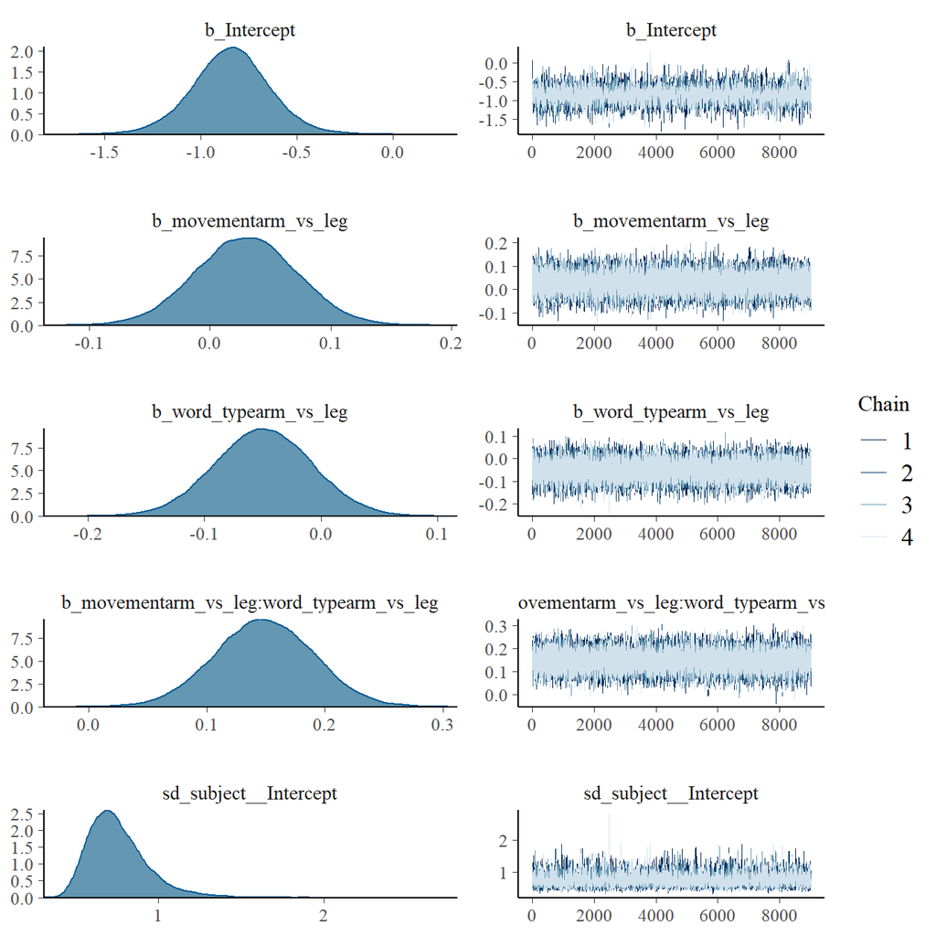

```r
plot(bfm_binom)
```

## 6.5 However, the effect size is small

However, while the effect seems to be there, an effect size of 0.15 log-odds is small. For instance, according to the guidelines proposed by Chen, Cohen, and Chen (2010), an effect of 0.5 log-odds would be considered a “small” effect. The current effect being less than one third of this could even be considered very small.

# 7 GLMM with *lme4*

As a sanity check, we also fit a frequentist version of the GLMM above with the *lme4* package. Do we roughly obtain the same estimates?

We fit an equivalent model to the one above:

```r
fm_binom <- glmer(
  cbind(errors, n - errors) ~ 1 + movement * word_type + (1 | subject),
  data = d, family = "binomial"
  )
summary(fm_binom)
```

```
## Generalized linear mixed model fit by maximum likelihood (Laplace
##   Approximation) [glmerMod]
##  Family: binomial  ( logit )
## Formula:
## cbind(errors, n - errors) ~ 1 + movement * word_type + (1 | subject)
##    Data: d
##
##      AIC      BIC   logLik deviance df.resid
##    399.1    409.6   -194.5    389.1       55
##
## Scaled residuals:
##     Min      1Q  Median      3Q     Max
## -3.0041 -0.8189 -0.1012  0.8675  2.2297
##
## Random effects:
##  Groups  Name        Variance Std.Dev.
##  subject (Intercept) 0.4319   0.6572
## Number of obs: 60, groups:  subject, 15
##
## Fixed effects:
##                                        Estimate Std. Error z value
## (Intercept)                            -0.84189    0.17530  -4.802
## movementarm_vs_leg                      0.02979    0.04147   0.718
## word_typearm_vs_leg                    -0.04949    0.04147  -1.193
## movementarm_vs_leg:word_typearm_vs_leg  0.14793    0.04149   3.566
##                                        Pr(>|z|)
## (Intercept)                            1.57e-06 ***
## movementarm_vs_leg                     0.472472
## word_typearm_vs_leg                    0.232732
## movementarm_vs_leg:word_typearm_vs_leg 0.000363 ***
## ---
## Signif. codes:  0 '***' 0.001 '**' 0.01 '*' 0.05 '.' 0.1 ' ' 1
##
## Correlation of Fixed Effects:
##             (Intr) mvmn__ wrd___
## mvmntrm_vs_ -0.003
## wrd_typrm__  0.005 -0.047
## mvmnt__:___ -0.013  0.018 -0.013
```

Indeed the point estimates are almost identical:

```r
tibble(
  Coefficient = rownames(fixef(bfm_binom)),
  brms = fixef(bfm_binom)[, 1],
  lme4 = fixef(fm_binom)
) %>%
  kable(digits = 3)
```

| Coefficient | brms | lme4 |
| --- | --- | --- |
| Intercept | -0.843 | -0.842 |
| movementarm_vs_leg | 0.030 | 0.030 |
| word_typearm_vs_leg | -0.050 | -0.049 |
| movementarm_vs_leg:word_typearm_vs_leg | 0.149 | 0.148 |

Note that the estimated SEMs for the fixed-effects coefficients also are quite comparable. This shows that our results are not specific to using Bayesian GLMMs (in `brms`).

# 8 Is the effect we find in the sample robust? Apply bootstrapping

Markus wondered if the apparently robust interaction effect observed in the original data might hinge on just a few participants who are driving the effect. One way of assessing this is through bootstrapping.

Bootstrap procedure:

1. Take a random sample of size 15 with replacement from the 15 participants in the original study.
2. Analyze the data set with the *lme4* model above (faster than *brms*).
3. Extract the estimates for the coefficient and its SE.
4. Repeat steps 1–3 a large number of times (e.g., 5000)

## 8.1 Bootstrapping

Basic function:

```r
# Function for a single run:
mybootstr <- function(df = d) {

  # Create new data set by resampling Subjects with replacement
  # (NB: Relies on dplyr functions, see in particular nest())
  newd <- df %>%
    nest(-subject) %>%
    sample_n(15, replace = TRUE) %>%
    mutate(subject = 1 : 15) %>%  # assign each resampled S a unique ID
    unnest()

  # contrast coding for movement and wordtype
  newd$movement <- factor(newd$movement)
  contrasts(newd$movement) <- contr.sum(2)
  newd$word_type <- factor(newd$word_type)
  contrasts(newd$word_type) <- contr.sum(2)

  # Fit glmer model
  fm_binom <- glmer(
    cbind(errors, n - errors) ~ 1 + movement * word_type + (1 | subject),
    data = newd, family = "binomial"
    )

  # extract point estimate and SE for interaction coefficient of interest, based
  # on https://r.789695.n4.nabble.com/extracting-coefficients-from-lmer-td791247.html
  beta <- fixef(fm_binom)[4]
  SE   <- sqrt(diag(vcov(fm_binom, useScale = FALSE))[4])
  zval <- beta / SE
  # out
  out <- c(beta, SE, zval)
  names(out) <- c("beta", "SE", "zval")
  out
}
```

Call it once or 4 times (with `replicate()`):

```r
# Run once
mybootstr()
```

```
##       beta         SE       zval
## 0.18050898 0.04164501 4.33446872
```

```r
# Using replicate
data.frame(t(replicate(4, mybootstr())))
```

```
##         beta         SE     zval
## 1 0.14681062 0.04058096 3.617722
## 2 0.12680779 0.04247595 2.985402
## 3 0.18789504 0.04106418 4.575644
## 4 0.08798495 0.04028827 2.183885
```

Run the function a large number of times and save results:

```r
# # Run and save to disk
# bootstr_res <- data.frame(t(replicate(5000, mybootstr())))
# write_csv(bootstr_res, "data/bootstrap_results.csv")
```

Once run, read from disk:

```r
# Read from disk
bootstr_res <- read_csv("data/bootstrap_results.csv")
# str(bootstr_res)
head(bootstr_res)
```

```
## # A tibble: 6 x 3
##     beta     SE  zval
##    <dbl>  <dbl> <dbl>
## 1 0.0872 0.0456  1.91
## 2 0.111  0.0402  2.77
## 3 0.112  0.0397  2.82
## 4 0.117  0.0426  2.75
## 5 0.205  0.0448  4.59
## 6 0.139  0.0417  3.33
```

## 8.2 Plot results

We plot the distribution of

1. beta estimates for the coefficient of interest (the critical interaction)
2. the SE for that coefficient
3. the $z$-value for that coefficient (this is just the ratio of the two above)

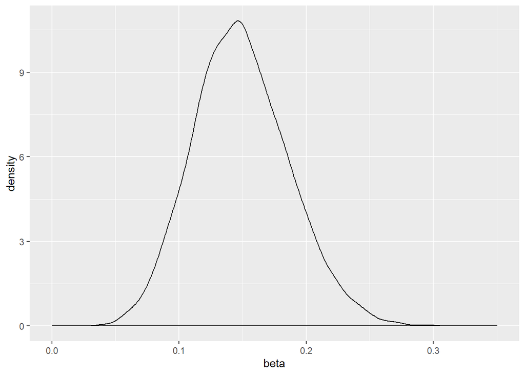

```r
ggplot(bootstr_res, aes(x = beta)) +
  geom_density() + xlim(0, 0.35)
```

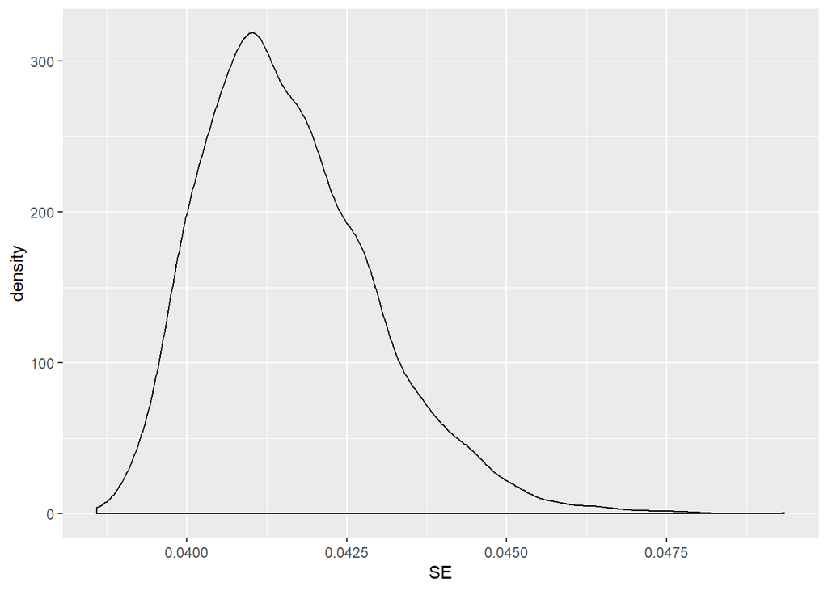

```r
ggplot(bootstr_res, aes(x = SE)) +
  geom_density()
```

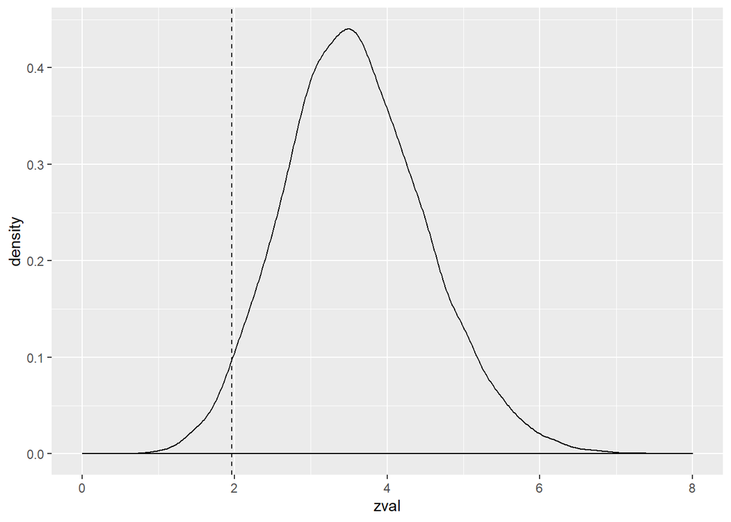

```r
ggplot(bootstr_res, aes(x = zval)) +
  geom_density() + xlim(0, 8) +
  geom_vline(xintercept = 1.96, linetype = "dashed")
```

What is the proportion of runs in which $z < 1.96$ (i.e., a non-significant effect)?

```r
with(bootstr_res, sum(zval < 1.96) / length(zval))
```

```
## [1] 0.0298
```

Based on bootstrapping it does not seem that the effect is very sensitive to a few exceptional participants within the sample. But of course it could still be that the sampled data itself (in the experiment) was exceptional, leading to a conclusion that would not scale up to the larger population.